# Logistic regression

January 20, 2022

## Gneralized liner model

Generalized linear model (**GLM**) is a generalization of linear regression. The **GLM** generalizes linear regression by allowing the linear model to be related to the response variable with a **link function** and by allowing the magnitude of the variance of each measurement to be a function of its predicted value. **Components of GLM:**

- *Random component*: Response variable \(y\) and it’s distribution. The observations \(y = (y_1,..y_n)^T\) on that are considered to be independent;
- *Linear predictor*: Suppose that we have parameter vector \(\beta = (\beta_1,...\beta_p)^T\) and a \(n\times p\) matrix \(X\) that contains values of \(p\) explanatory variables for \(n\) observations. Then the *linear predictor* is \(\{\eta_i\} = X\beta\) where \(\eta_i = \sum\limits_{j=1}^{p} \beta_j\cdot x_{ij}\);
- *Link function* This is function \(g\) applied to every component of E(y) that relates it to the linear predictor i.e \(g(E(y_i)) = g(\mu_i) = \eta_i\)

## Models for Binary Data

For binary(YES/NO) responses we usually assume binomial distribution for the random component \(y\). Most commonly used link function for this kind of models is called *logit* for which the model itself is referred to as *logistic regression*. It has been used to model an abundance of studies including bio-medical and social science researches and marketing applications.

In creating our models, we firstly need to distinguish between two data formats; We let \(\textbf{n} := (n_1,..,n_N)\) be vector containing numbers of Bernoulli trials for which \(y_i\) is *“proportion of success”* i.e. \(n_i\cdot y_i \thicksim Bin(n_i,\pi_i)\), and \(n:=\sum\limits_{i=1}^{N}n_i\) be overall number of observations; When \(\textbf{n} = (1,...1)\) we have *ungrouped* data format. Data takes this form when each y_i is realization of single *Bernoulli trial*. Otherwise, we are dealing with *grouped* data where sets of observations have the same value for each explanatory variable. The same maximum likelihood estimates \(\hat{\beta}\) and standard errors occur for both formats, however some other measures of fit change. Nevertheless, an ungrouped data can be converted to grouped format.

## Models for Binary Data

Let us now assume that there is unobserved continuous response \(y_i^* = \sum\limits_{j=1}^{p} \beta_j\cdot x_{ij} + \epsilon_i\) for the i-th subject,where \(\epsilon_i\) is independent from a distribution and has mean \(0\) and c.d.f \(F\) which is symmetric around the mean. Let \(c\) be the constant s.t. we observe \(y_i = 0\) when \(y_i^* \leq c\) and \(y_i \gt c\). WLOG we can take \(c\) to be \(0\);We’ve thus defined approach called *threshold model* used for different families of GLMs. Further, note that

\[\pi_i = E(y_i) = P(y_i = 1) = P(y_i^*\gt c) \\ = P(\sum\limits_{j=1}^{p} \beta_jx_{ij} + \epsilon_i \gt c) = 1 - P(\epsilon_i \lt c - \sum\limits_{j=1}^{p} \beta_j x_{ij}) \\ = 1 - F(-\sum\limits_{j=1}^{p} \beta_jx_{ij}) = F(\sum\limits_{j=1}^{p} \beta_j x_{ij})\]

## Properties and interpretations of Logistic regression

For the cumulative distribution function in our model we take c.d.f of *logistic distribution* \(F(z) = \frac{e^z}{1+e^z}\) which has bell-shaped density function defined over the entire real line with mean \(0\). The function \(F^{-1}(p) = log(\frac{p}{1-p})\) is called *logit*. We’ve thus derived formulas

\[\pi_i = \frac{e^{\eta_i}}{1 +e^{\eta_i}} \\ logit(\pi_i) = log(\frac{\pi_i}{1-\pi_i}) = \eta_i = \sum\limits_{j=1}^{p} \beta_j x_{ij} \]

In the case of single quantitative explanatory variable with \(\beta \gt 0\), the curve \(\pi_i = \frac{e^{\beta x_i}}{1+e^{\beta x_i}}\) approaches 1 at the same rate that it approaches 0; In the case of multiple explanatory variables we note that \(1-\pi = \frac{1}{1+exp({\sum\limits_{j=1}^{p} \beta_j x_{ij}})}\) and that function is monotone in each explanatory variable \(x_{ij}\) according to the sign of \(\beta\). Moreover, deriving with respect to the each \(x_{ij}\), we get that \(\frac{d\pi_i}{dx_{ij}} = \beta_j \pi_i (1-\pi_i)\) and observe that \(\beta_j\) determines the rate of change of πi as \(x_{ij}\) changes.

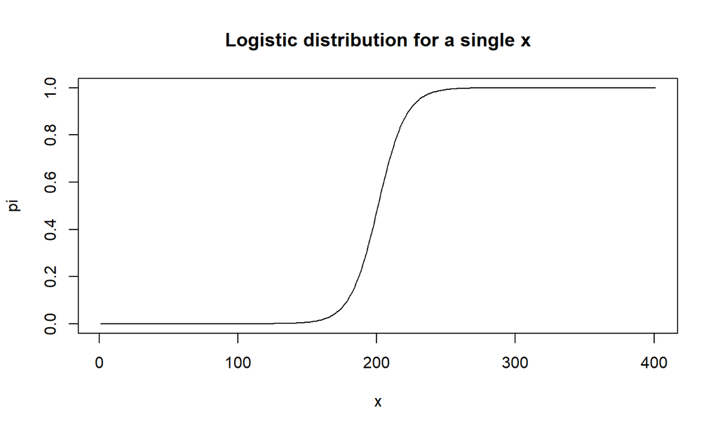

## Qualitative explanatory variable

We first look at the case of a single binary indicator \(x_{ij}\); For the model \(logit(\pi_i)=log(\frac{\pi_i}{1-\pi_i})=\beta_0+\beta_1x_{i}\) we have that \(\beta_1 = \beta_0+\beta_1\cdot1 - \beta_0 - \beta_1\cdot0=logit(P(y_i=1|x_i=1))-logit(P(y_i=1|x_i=0))\). It follows that \[e^{\beta_1} = \frac{e^{logit(P(y_i=1|x_i=1))}}{e^{logit(P(y_i=1|x_i=1))}}=\frac{e^{log\frac{P(y_i=1|x_i=1)}{1-P(y_i=1|x_i=1)}}}{e^{log\frac{P(y_i=1|x_i=0)}{1-P(y_i=1|x_i=0)}}} = \frac{\frac{P(y_i=1|x_i=1)}{1-P(y_i=1|x_i=1)}}{\frac{P(y_i=1|x_i=0)}{1-P(y_i=1|x_i=0)}}\] Therefore odds ratio can be associated with \(2\times2\) contingency table.  
With multiple variables \(\{x_{ij}\}\), we exponentiate both sides of the equation for the \(logit(\pi)\) to see that the odds$_i/(1-_i) $ are an exponential function of \(x_{ij}\) for each \(j\);

## Contingency table

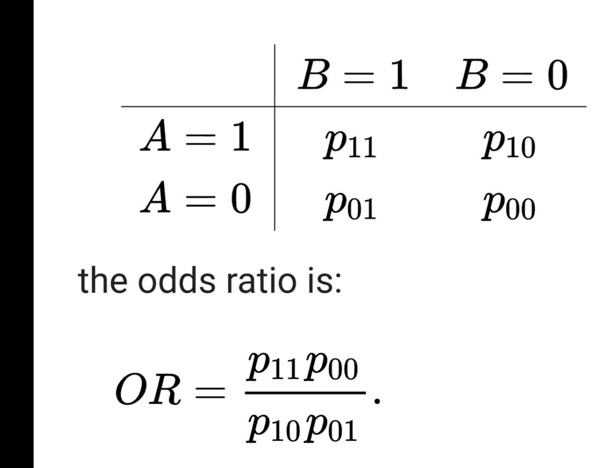

## Summary of Predictive Power

A classification table describes the predicted number of successes/failures(\(\hat y = 1/0\)) compared with the number of successes/failures actually observed(\(y=1/0\)). For the ungrouped data model, we predict \(\hat y = 1\) when \(\hat \pi_i \gt \pi_0\), and \(\hat y = 0\) for \(\hat \pi_i \leq \pi_0\) for selected cutoff \(\pi_0\); Common cutoffs are \(\pi_0 = 0.5\) and \(\pi_0 = \frac{\#\{y_i=1\}}{n}\); Rather than using \(\hat \pi_i\) fitted to the dataset that includes \(y_i\) it’s better to make the prediction model fitted to other \(n-1\) observations. For a particular cutoff, summaries of the predictive power from a classification table are estimates of sensitivity and specificity i.e. \(P(\hat y = 1|y = 1)\) and \(P(\hat y = 0|y = 0)\)  
A more precise approach than cllasification table for fixed \(\pi_0\) considers estimated sensitivity and specificity for all possible \(\pi_0\); The sensitivity is the ratio of true positives and 1-specificity or \(P(\hat y = 1 | y = 0)\) , is the false positives rate; A plot of the true positives rate as the function of false positives rate as \(\pi_0\) decreases from 1 to 0 is called receiver operating (*ROC*) curve;

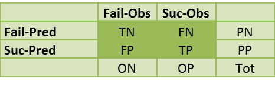

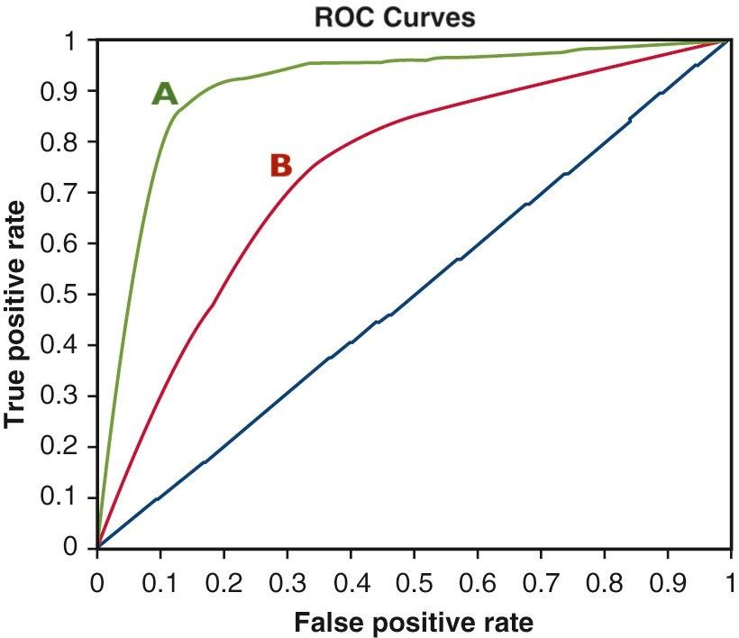

## Case control studies

In the case control studies, two existing groups differing in outcome are identified and compared on the basis of some supposed causal attribute. More precissely the values of the response variable \(y\) are known, and and researchers look into the past to observe values of random variable \(x\). Recall that, for the case of single qualitative variable we obtained: \[e^{\beta_1} = \frac{\frac{P(y_i=1|x_i=1)}{P(y_i=0|x_i=1)}}{\frac{P(y_i=1|x_i=0)}{P(y_i=0|x_i=0)}} \] By applying *Bayes Theorem* we get that \[ e^\beta_1 = \frac{\frac{P(x_i=1|y_i=1)}{P(x_i=0|y_i=1)}}{\frac{P(x_i=1|y_i=0)}{P(x_i=0|y_i=0)}}\] This tells us that it is possible to estimate the odds ratio in retrospective studies that sample x, for given y.

## Justification

We let \(z\) be indicator variable that has value 1 if a subject is sampled and 0 otherwise; Even if we don’t know conditional distribution of y given x, we are able to model for \(P(y = 1|z =1,x)\) assuming logistic model for \(P(y = 1|x)\) By *Bayes Theorem* \[P(y= 1|z=1,x) = \frac{P(z= 1|y=1,x)P(y=1|x)}{\sum\limits_{j=0}^{1}P(z= 1|y=j,x)P(y=j|x)}\] We assume \(P(z= 1|y=1,x) = P(z= 1|y=1)\) let \(p_1 := P(z= 1|y=1)\) and \(p_0 := P(z= 1|y=0)\). Also we divide both the numerator and denominator in the last equation by \(P(y=0|x)\)(note: \(P(y=1|x)/P(y=0|x) = e^{\beta_0 + \beta_1x}\) to obtain \[P(y=1|z = 1, x) = \frac{p_1\cdot e^{\beta_0 + \beta_1x}}{p_0 + p_1\cdot e^{\beta_0 + \beta_1x}}\] Then, letting \(\beta_0' = \beta_0 + log(p_1/p_0)\) gives us \(logit[P(y=1|z = 1, x)] = \beta_0' + \beta_1x\); So we again have regression model with the same parameters, only that now we can’t estimate the intercept as we don’t know \(p_0,p_1\);

## Example: Lung cancer study

In one of the first studies about the link between lung cancer and smoking Richard Doll and Austin Bradford Hill collected data from 20 hospitals. Patients diagnosed with lung cancer were queried about their smoking behavior;In both cancer-diagnosed and control group, there was 709 patients, and control group was made of a noncancer patients at the same hospital; Person who had smoked at least one cigarette a day for at least a year was defined as a smoker; Among lung-cancer patients 688 reported being smokers while there was 650 smoker in non cancer group;  
Referring to obtain results,we can setup our GLM \(logit[\pi_i] = \beta_0' + \beta_1x\), and estimate parameter \(\beta_1\);

```r
lsm1 <- rep(1,688);
lsm0 <- rep(0,21);
csm1 <- rep(1,650);
csm0 <- rep(0,59);
cancer = cbind(rep(1,709),c(lsm1,lsm0))
control =cbind(rep(0,709),c(csm1,csm0))
df <- as.data.frame(rbind(cancer,control))
colnames(df) <-c("y","x")
```

## Example: Lung cancer study

```r
summary(glm(y~x,family = "binomial",data = df))
```

```
##
## Call:
## glm(formula = y ~ x, family = "binomial", data = df)
##
## Deviance Residuals:
##     Min       1Q   Median       3Q      Max
## -1.2016  -1.2016   0.1865   1.1534   1.6356
##
## Coefficients:
##             Estimate Std. Error z value Pr(>|z|)
## (Intercept)  -1.0330     0.2541  -4.065 4.80e-05 ***
## x             1.0898     0.2599   4.193 2.75e-05 ***
## ---
## Signif. codes:  0 '***' 0.001 '**' 0.01 '*' 0.05 '.' 0.1 ' ' 1
##
## (Dispersion parameter for binomial family taken to be 1)
##
##     Null deviance: 1965.8  on 1417  degrees of freedom
## Residual deviance: 1945.9  on 1416  degrees of freedom
## AIC: 1949.9
##
## Number of Fisher Scoring iterations: 4
```

## Example: Lung cancer study

As we can see from summary of our model, estimate of effect parameter \(\hat \beta_1 = 1.0898\) with standard deviation \(\hat\delta = 0.2599\) and *p-value* smaller than \(10^{-4}\) which indicates accuracy of our estimate;

## Example: Lung cancer study

```r
shufled <- df[sample(1:nrow(df)), ]
tst <-shufled[1:709,]
mdl <-glm(y~x,family = "binomial",data = df)
pred <- predict(mdl,tst,"response")
pred <-ifelse(pred>0.5,1,0)

length(tst[tst$y==1,1])
```

```
## [1] 347
```

```r
table(tst$y,pred)
```

```
##    pred
##       0   1
##   0  28 334
##   1   9 338
```

## Example (Crabs data)

Before we proceed with the description of our model we’ll introduce goodness-of-fit statistic called *deviance*;The deviance is a log-likelihood ratio statistics that compares the GLM model fitted using more parameters with the model with smaller number of parameters; Let \(\theta = (\theta_1,...,\theta_N)\) vector containing the parameters of the saturated model, and \(\theta'\) vector containing parameters of unsaturated model with number of parameters \(<N\). Let \(\hat\theta\) be the maximal likelihood estimates for the saturated model and \(\hat\theta'\) maximal likelihood estimates for the unsaturated one. The deviance is defined as \(D = 2log(\frac{\mathcal{L}(\hat\theta)}{\mathcal{L}(\hat\theta')})\);  
Now we are given dataset *Crabs.dat* which contains information about weight, color and number of satellites(column *y*) of a female crabs. We set \(y=1\) when a crab contain at least one satelite, otherwise we set \(y=0\). We firstly fit a main-effect logistic model using weight and color as our exploratory variables and we fit second model after that, for which we’ll allow interaction between color and weight. Finally we’ll compare those to models.

```r
crabs = read.table("https://users.stat.ufl.edu/~aa/glm/data/Crabs.dat",skip = 1)
colnames(crabs)<-c("crab",  "y", "weight", "width", "color" ,"spine")
crabs$y <- ifelse(crabs$y>0,1,0)
mdl1 = glm(y~weight+color,"binomial",crabs)
mdl2 = glm(y~weight*color,"binomial",crabs)
```

## Example(Crabs data)

```r
summary(mdl1)
```

```
##
## Call:
## glm(formula = y ~ weight + color, family = "binomial", data = crabs)
##
## Deviance Residuals:
##     Min       1Q   Median       3Q      Max
## -2.1596  -0.9998   0.5237   0.8825   1.9109
##
## Coefficients:
##             Estimate Std. Error z value Pr(>|z|)
## (Intercept)  -2.0316     1.1161  -1.820   0.0687 .
## weight        1.6531     0.3825   4.322 1.55e-05 ***
## color        -0.5142     0.2234  -2.302   0.0213 *
## ---
## Signif. codes:  0 '***' 0.001 '**' 0.01 '*' 0.05 '.' 0.1 ' ' 1
##
## (Dispersion parameter for binomial family taken to be 1)
##
##     Null deviance: 225.76  on 172  degrees of freedom
## Residual deviance: 190.27  on 170  degrees of freedom
## AIC: 196.27
##
## Number of Fisher Scoring iterations: 4
```

## Example(Crabs data)

For the first regression model,\(logit[P(y_i=1)] = \beta_0+\beta_1x_{i1}+\beta_2x_{i2}\), we’ve obtained estimates \(\hat \beta_0 = -2.0316\),\(\hat \beta_1 = 1.6531\),\(hat \beta_2 =-0.5142\), with standard errors \(\hat\delta_1 = 1.1161\),\(\hat\delta_2 = 0.3825\),\(\hat\delta_3 = 0.2234\) respectively.  
## Example(Crabs data)

```r
summary(mdl2)
```

```
##
## Call:
## glm(formula = y ~ weight * color, family = "binomial", data = crabs)
##
## Deviance Residuals:
##     Min       1Q   Median       3Q      Max
## -2.1355  -0.9909   0.5291   0.8781   1.9871
##
## Coefficients:
##              Estimate Std. Error z value Pr(>|z|)
## (Intercept)   -1.1890     3.1959  -0.372    0.710
## weight         1.2885     1.3487   0.955    0.339
## color         -0.8506     1.2227  -0.696    0.487
## weight:color   0.1468     0.5239   0.280    0.779
##
## (Dispersion parameter for binomial family taken to be 1)
##
##     Null deviance: 225.76  on 172  degrees of freedom
## Residual deviance: 190.19  on 169  degrees of freedom
## AIC: 198.19
##
## Number of Fisher Scoring iterations: 4
```

## Example(Crabs data)

```r
deviance(glm(y~weight+color,"binomial",crabs))-deviance(glm(y~weight*color,"binomial",crabs))
```

```
## [1] 0.07910717
```

```r
anova(mdl1, mdl2, test = "Chisq")
```

```
## Analysis of Deviance Table
##
## Model 1: y ~ weight + color
## Model 2: y ~ weight * color
##   Resid. Df Resid. Dev Df Deviance Pr(>Chi)
## 1       170     190.27
## 2       169     190.19  1 0.079107   0.7785
```

## Example (Crabs2 data)

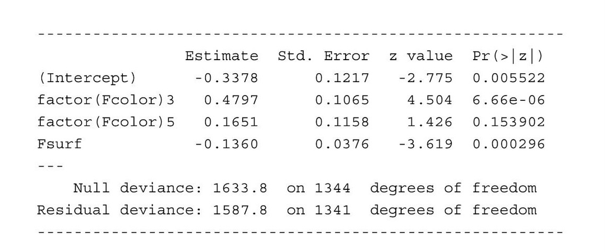

The dataset Crabs2.dat collects several variables that may be associated with y = whether a female horseshoe crab is monandrous (eggs fertilized by a single male crab) or polyandrous (eggs fertilized by multiple males). A probit model that uses as explanatory variables Fcolor = the female crab’s color (1 = dark, 3 = medium, 5 = light) and Fsurf = her surface condition (values 1, 2, 3, 4, 5 with lower values representing worse) has the output shown. Interpret the parameter estimates and the inferential results. Approximately what values would you expect for the ML estimate of the Fsurf effect and its SE if you fitted the corresponding logistic model?